# Sell in May and Go Away

Nicolás Forteza

# Carga de Datos

```r
library(quantmod)
library(moments)
library(ggplot2)
library(ggfortify)
library(plyr)
library(pander)
library(readr)
library(ggthemes)
library(forecast)
library(xts)
library(gridExtra)
library(knitr)
datos <- read_csv2("~/Desktop/MASTER/Predicción /Notas Prof/Data/LCXP.csv")
```

Tenemos que proceder en primer lugar a la estructuración de la serie temporal para que podamos trabajar adecuadamente con ella. El paquete XTS nos proporciona las herramientas adecuadas para el análisis de series temporales.

```r
serie.temporal=xts(datos$Precio, order.by = as.Date(datos$Fecha,"%Y-%m-%d"),frequency=365)
```

Tenemos la serie temporal desde diciembre de 1991 hasta agosto de 2015.

# Verificación de la Estrategia.

Se nos pide ver en nuestros datos históricos si entre noviembre y abril es verdad que los returns son mayores que en el periodo dado entre mayo y octubre. Se dice que esto se puede dar por varios motivos. Hay quien dice que es porque entre noviembre y abril se dan los mayores gastos por parte de los agentes económicos (cierre de ejercicios, navidades, etc). Por otro lado, el hecho de que en el periodo de mayo-octubre haya más vacaciones hace creer que estos periodos sean más volátiles. Históricamente, mayo es de los peores meses en lo que respecta a rentabilidad, y en octubre es cuando más crashes bursátiles ha habido.

Una primera aproximación es ver en los charts que efectivamente tenemos rentabilidades mensuales mayores entre los meses de noviembre y abril. A continuación podemos ver la rentabilidad media mensual.

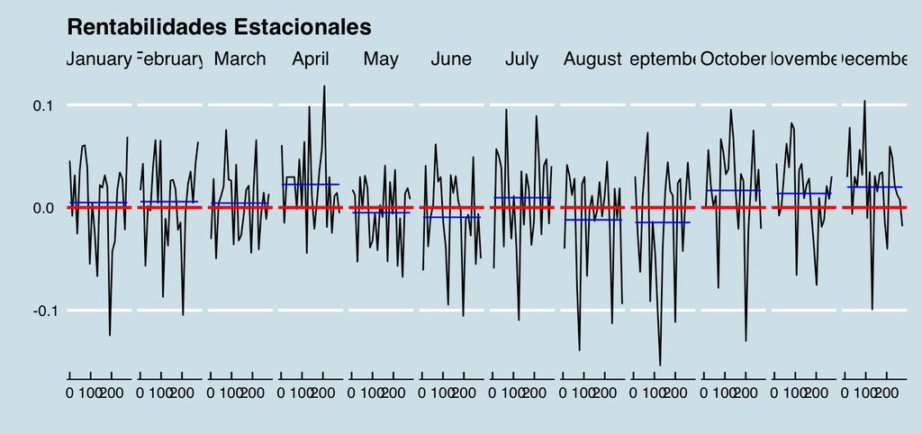

```r
dRentCont=monthlyReturn(serie.temporal,type='log',leading=FALSE)
monthly.log.returns=na.omit(dRentCont)
ggfreqplot(as.ts(monthly.log.returns,0),freq=12,nrow=1,facet.labeller=month.name)+
  ggtitle("Rentabilidades Estacionales")+
  geom_hline(yintercept = 0,color="red",size=1)+
  theme_economist()
```

```r
meses <- serie.temporal[xts:::startof(serie.temporal, "months")]
noviembre <- meses[.indexmon(meses)==10]
octubre <- meses[.indexmon(meses)==9]
diciembr <- meses[.indexmon(meses)==11]
mayo <- meses[.indexmon(meses)==4]
mayo <- mayo[-1,]
```

Viendo el t.test del periodo de noviembre (primer dia) a mayo (primer dia), vemos que las rentabilidades son significativas. Entonces se verifica que la estrategia se ha dado a lo largo de los años.

```r
#noviembre-mayo
df1 <- rbind.xts((noviembre),(mayo))
rentabilidades1 <- monthlyReturn(df1,type="arithmetic")
rentabilidades1 <- rentabilidades1[.indexmon(rentabilidades1)==4]
t.test1 <- t.test(rentabilidades1)
P_Value <- t.test1$p.value
Media <- mean(rentabilidades1)
df <- data.frame(P_Value,Media,row.names = "Estadistico")
colnames(df)<- c("P-Value","Media")
kable(df)
```

|  | P-Value | Media |
| --- | --- | --- |
| Estadistico | 0.0049678 | 0.081748 |

Como vemos, tenemos una rentabilidad del 8% de media en cada año. Sin embargo, comprando el primero de octubre y vendiendo el primero de mayo obtenemos más rentabilidad aún.

```r
df2 <- rbind.xts((octubre),(mayo))
rentabilidades2 <- monthlyReturn(df2,type="arithmetic")
rentabilidades2 <- rentabilidades2[.indexmon(rentabilidades2)==4]
t.test2 <- t.test(rentabilidades2)
P_Value <- t.test2$p.value
Media <- mean(rentabilidades2)
df <- data.frame(P_Value,Media,row.names = "Estadistico")
colnames(df)<- c("P-Value","Media")
kable(df)
```

|  | P-Value | Media |
| --- | --- | --- |
| Estadistico | 0.0020939 | 0.1040357 |

Y comprando el primero de diciembre?

```r
df3 <- rbind.xts((diciembr),(mayo))
rentabilidades3 <- monthlyReturn(df3,type="arithmetic")
rentabilidades3 <- rentabilidades3[.indexmon(rentabilidades3)==4]
t.test3 <- t.test(rentabilidades3)
P_Value <- t.test3$p.value
Media <- mean(rentabilidades3)
df <- data.frame(P_Value,Media,row.names = "Estadistico")
colnames(df)<- c("P-Value","Media")
kable(df)
```

|  | P-Value | Media |
| --- | --- | --- |
| Estadistico | 0.0044351 | 0.0648006 |

Podemos ver la rentabilidad de cada año según cada estrategia:

```r
#Comparación estrategias
estrategias <- cbind.data.frame(rentabilidades1,rentabilidades2,rentabilidades3)
colnames(estrategias)<-c("Rentabilidad por año Nov-May","Rentabilidad por año Oct-May","Rentabilidad por año Dic-May")
kable(estrategias)
```

|  | Rentabilidad por año Nov-May | Rentabilidad por año Oct-May | Rentabilidad por año Dic-May |
| --- | --- | --- | --- |
| 1993-05-03 | 0.1189173 | 0.1413650 | 0.0735337 |
| 1994-05-02 | 0.0243241 | 0.0814120 | 0.0168959 |
| 1995-05-01 | 0.0145390 | 0.0434192 | 0.0160399 |
| 1996-05-01 | 0.1427559 | 0.1403323 | 0.1041139 |
| 1997-05-01 | 0.2663510 | 0.2719976 | 0.1848591 |
| 1998-05-04 | 0.3428524 | 0.2537802 | 0.2943677 |
| 1999-05-03 | 0.2430365 | 0.4243544 | 0.2150689 |
| 2000-05-02 | 0.2662808 | 0.3499207 | 0.1636264 |
| 2001-05-02 | -0.1293631 | -0.1081537 | -0.0813361 |
| 2002-05-02 | 0.0222388 | 0.0969228 | -0.0036379 |
| 2003-05-02 | -0.0771735 | -0.0149693 | -0.1271564 |
| 2004-05-03 | 0.0635371 | 0.1379310 | 0.0538452 |
| 2005-05-02 | 0.0509609 | 0.0522986 | 0.0243805 |
| 2006-05-02 | 0.1529764 | 0.1202338 | 0.1028198 |
| 2007-05-02 | 0.0841892 | 0.1245402 | 0.1073728 |
| 2008-05-02 | -0.1360201 | -0.1344585 | -0.1108295 |
| 2009-05-04 | -0.1042673 | -0.2179075 | 0.0317468 |
| 2010-05-03 | 0.0802265 | 0.0801416 | 0.0466392 |
| 2011-05-02 | 0.0605736 | 0.0893250 | 0.0610662 |
| 2012-05-01 | 0.0911105 | 0.1489587 | 0.0730017 |
| 2013-05-01 | 0.0823893 | 0.0873769 | 0.0718489 |
| 2014-05-01 | 0.0469921 | 0.0757362 | 0.0386814 |
| 2015-05-01 | 0.1727774 | 0.1482628 | 0.1334666 |

Por lo tanto: se suele dar la rentabilidad positiva si compramos el primer dia del mes de noviembre y vendemos el primero de mayo. Habría que ver en qué momento hay que comprar y vender, pero por lo general vamos a tener una estrategia positiva. Incluso si compramos el primero de octubre o el primero de diciembre obtenemos una rentabilidad positiva y estamos avalando la teoría de que en los meses cercanos a la navidad es buen momento para comprar. De otro modo, podemos ver que del año 2002 al 2003 no hubo rentabilidad positiva en esta estrategia para ningún mes, y que los años del crash de la crisis, de 2007 a 2008, no se dio tampoco una estrategia favorable.